CAEL VESPER / GRIMORIO ILLUSTRATOD&D 2024 · LIVELLO 3

Il Dominio Oscuro

# Cael Vesper

Il Cartografo del Cielo Morto

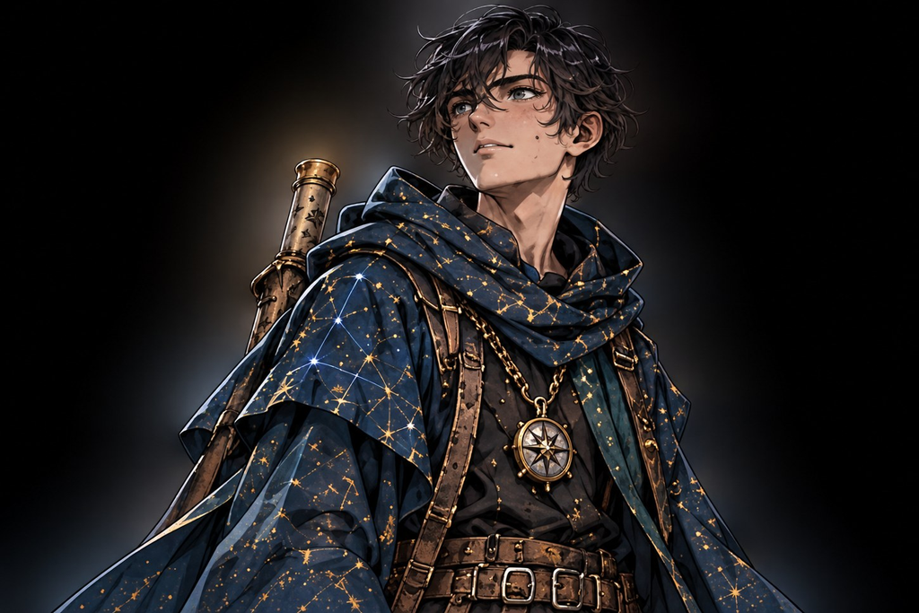

«Non so se le stelle siano ancora lassù.  
So che qualcuno si è preso parecchio disturbo  
per impedirci di guardare.»

**Umano · Druido 3 · Guida**  
Ordine primordiale: Magician  
Sottoclasse prevista: Circolo delle Stelle, dal 3°.

**Edizione illustrata v1 · 10.10.2026**  
Compagna della scheda da tavolo.  
Le scelte ancora aperte restano tali.

Riferimenti: Player’s Handbook 2024, pagine inglesi riportate nella scheda verificata. Non sono numeri di pagina dell’edizione italiana. Distanze: 5 piedi = 1,5 m. Illustrazioni originali già presenti nella raccolta di Cael.

CAEL VESPER / INDICED&D 2024 · LIVELLO 3

Grimorio illustrato

# Una guida alla consultazione

Usa la scheda da tavolo durante il turno; queste pagine conservano dettagli, eccezioni e contesto. I riferimenti al manuale accompagnano ogni capacità.

### In combattimento

*Incremento fisso, da confermare con il DM.

### Come leggere

**A** azione · **AB** azione bonus  
**TS** tiro salvezza · **CONC** concentrazione  
**V, S, M** componenti dell’incantesimo.

Personaggio e risorse**03**

Specie, background e talenti**04**

Magia e capacità di classe**05**

Forma Selvatica e Wild Companion**06**

Attacchi, armi e dotazione**07–09**

Incantesimi illustrati**10–21**

Find Familiar: il compagno**22**

Concentrazione e condizioni**23**

Il Dominio Oscuro e storia**24–25**

Avanzamento alle Stelle**26–27**

### Tre stati, sempre distinti

**Da concordare al tavolo:** forme animali, famiglio, lingue, bastone-focus e «luce viva». Le varianti del Dominio Oscuro sono separate dalle regole del manuale.

CAEL VESPER / SCHEDA DA TAVOLOD&D 2024 · LIVELLO 3

Il Cartografo del Cielo Morto

# Cael Vesper

**Druido 3 · Umano · Guida**  
Ordine: Magician · Il Dominio Oscuro  
Circolo delle Stelle: attivo.

«Non serve credere alle stelle.  
Serve sapere dove puntare.»

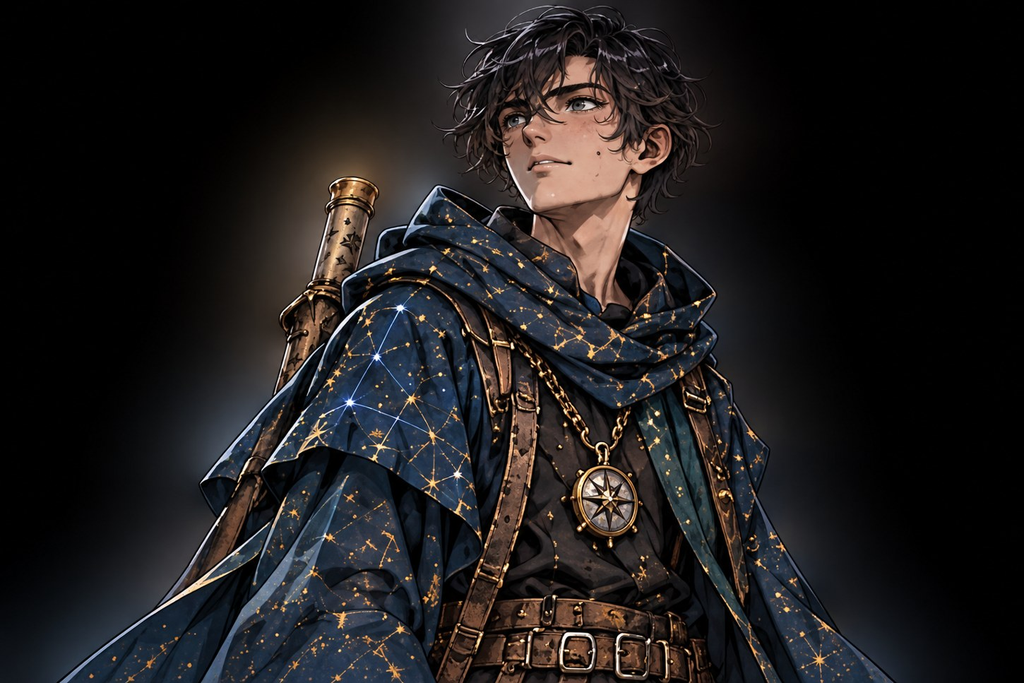

**Livello 3 · Circolo delle Stelle attivo.** Slot: 4 di 1° e 2 di 2°. Preparati: Healing Word, Cure Wounds, Entangle, Faerie Fire, Moonbeam, Pass without Trace. Thunderwave non preparato. Star Map: Guidance e Guiding Bolt; 4 Guiding Bolt gratuiti per riposo lungo. Starry Form: Arciere, Calice, Drago.

CA**16**14 senza scudo

PF massimi**27***attuali _____

Iniziativa**+5**DES + Alert

Velocità**9 m**30 piedi

Perc. passiva**16**Percezione +6

Competenza**+2**livello 2

FOR 10**+0**TS +0

DES 16**+3**TS +3

COS 17**+3**TS +3

INT 10**+0**TS +2 •

SAG 18**+4**TS +6 •

CAR 10**+0**TS +0

Abilità e competenze

Percezione •**+6**

Natura •**+6**

Furtività •**+5**

Sopravvivenza •**+6**

Indagare •**+2**

Arcana**+4**

Cartografia **+6 (SAG)** · Erboristeria **+2 (INT)**  
• = competente. Magician già incluso in Natura e Arcana.  
TS e classe: pp. 78–80; Guida p. 181; Umano p. 194.

**Lingue:** Comune, Druidico; altre da scegliere.  
**Addestramento:** armi semplici, armature leggere, scudi.

Risorse · compila alla sessione

**Slot di 1°**

**Slot di 2°**

**Forma Selvatica**

**Guiding Bolt gratuito (Star Map)**

**Goodberry senza slot**

**Ispirazione Eroica**

Slot e Goodberry: riposo lungo. Forma Selvatica: 1 uso al breve, tutti al lungo (pp. 79–80, 201).  
Dadi vita **3d8** · PF temporanei ____ · Esaustione ____  
*27 PF a incremento fisso: da confermare con il DM.

Capacità in un colpo d’occhio

**Forma Selvatica · 1 AB** — 2 usi, dura 1 h; GS ≤ 1/4, niente volo. Mantieni i tuoi PF, ottieni 2 PF temporanei; non lanci incantesimi. 4 forme da scegliere. p. 80

**Wild Companion · 1 A Magia** — spendi 1 slot o 1 uso di Forma Selvatica: famiglio Fatato senza materiali. Scompare al riposo lungo. Forma da scegliere. p. 81

**Alert** — iniziativa +5 già calcolata; dopo il tiro puoi scambiarla con un alleato consenziente. Nessuno dei due deve essere Incapacitated. p. 200

**Umano** — Ispirazione Eroica dopo il riposo lungo: ritira un dado appena tirato, usando il nuovo risultato. pp. 194, 368

Attacchi con le armi

| Arma / configurazione | Attacco | Danno | Portata / nota |
| --- | --- | --- | --- |
| Bastone con Shillelagh* | **+6** | **1d8+4** | Mischia; forza o contundente |
| Bastone senza incantesimo | +2 | 1d6 | 1d8 a due mani; contundente |
| Falcetto | +2 | 1d4 | Mischia; tagliente, non Finesse |
| Arco corto | +5 | 1d6+3 | 24/96 m; due mani, no scudo |

Armi: pp. 215, 225. Cuoio + scudo: p. 219. Nessuna maestria d’arma attiva. *Formalizzare il bastone-focus come Quarterstaff; non è un nuovo acquisto.

**Concentrazione standard: +3**  
TS COS quando subisci danni: CD max(10, metà danni arrotondata per difetto), massimo 30. Un solo effetto. p. 363

**Variante di campagna: +7**  
Due effetti: CD minima 20; fallimento = perdi tutti. Non è il TS COS ordinario. In forma animale ricalcola la COS.

CAEL VESPER / PERSONAGGIOD&D 2024 · LIVELLO 3

Grimorio illustrato

# Origini e talenti

### Umano — Human

**Resourceful.** Ottieni Ispirazione Eroica quando termini un riposo lungo.

**Skillful.** Ottieni competenza in un'abilità a scelta. Per Cael la scelta già presente è **Indagare**, ora ricalcolata a +2.

**Versatile.** Ottieni un talento Origine. La scelta del personaggio è **Alert**. È aggiuntivo rispetto al talento del background: non sostituisce Magic Initiate.

**Ispirazione Eroica — Heroic Inspiration, PHB 2024 p. 368, .** Puoi spenderla per ritirare **un qualsiasi dado immediatamente dopo averlo tirato**; devi usare il nuovo risultato. Quando ne ricevi una mentre la possiedi già, la nuova è persa a meno che tu la dia a un personaggio giocante che ne è privo. Non si tratta soltanto di vantaggio su un tiro per colpire.

PHB 2024 (EN), pp. 194, 368.

### Guida — Guide

Conferisce competenza in **Furtività**, **Sopravvivenza** e **strumenti da cartografo**, oltre al talento **Magic Initiate (Druid)**. Le caratteristiche ammesse per gli incrementi sono Destrezza, Costituzione e Saggezza, distribuendo +2/+1 oppure +1 a tutte e tre: nella presente scheda i punteggi finali includono già quanto deciso dal giocatore.

La dotazione scelta è il pacchetto A: **arco corto, 20 frecce, faretra, strumenti da cartografo, giaciglio, tenda, abiti da viaggiatore e 3 mo**. Non è stato scelto il pacchetto alternativo in denaro.

PHB 2024 (EN), p. 181.

### Alert

**Categoria:** talento Origine. **Fonte:** PHB 2024 p. 200, . **Origine per Cael:** Versatile dell'umano.

**Initiative Proficiency.** Aggiungi il bonus di competenza al tiro di iniziativa: per Cael `1d20 + 3 + 2 = 1d20 + 5`.

**Initiative Swap.** Subito dopo aver tirato l'iniziativa puoi scambiare il tuo risultato con quello di **un alleato consenziente nello stesso combattimento**. Lo scambio non è possibile se tu o l'alleato avete la condizione Incapacitated.

Alert **non aumenta la CA** e questa versione non va sostituita con i benefici di un'altra edizione.

PHB 2024 (EN), p. 200.

### Magic Initiate — scelta Druid

**Categoria:** talento Origine. **Fonte:** PHB 2024 p. 201, . **Origine per Cael:** background Guide, p. 181.

Impari due trucchetti e scegli un incantesimo di 1° livello dalla stessa lista ammessa dal talento. La caratteristica magica può essere Intelligenza, Saggezza o Carisma; **Cael ha scelto Saggezza**.

| Scelta di Cael | Beneficio |
| --- | --- |
| Druidcraft | Trucchetto aggiuntivo rispetto a quelli di classe |
| Shillelagh | Trucchetto aggiuntivo; utilizza SAG per i benefici descritti nell'incantesimo |
| Goodberry | Sempre preparato; un lancio senza slot per riposo lungo; ulteriori lanci con slot |

Quando ottieni un nuovo livello puoi sostituire **uno** degli incantesimi scelti per questo talento con un altro dello stesso livello e della stessa lista. Il talento è ripetibile soltanto scegliendo ogni volta una lista differente. Nessuna scelta viene sostituita automaticamente da questa revisione.

PHB 2024 (EN), p. 201.

CAEL VESPER / CLASSED&D 2024 · LIVELLO 3

Grimorio illustrato

# La magia di Cael

### Spellcasting — livello 1

Recuperi gli slot spesi al termine di un riposo lungo e puoi cambiare la lista dei preparati dopo quel riposo, scegliendo incantesimi da druido di livelli per cui possiedi slot. Gli incantesimi che una capacità di classe rende sempre preparati non occupano posti nella lista ordinaria. Quando guadagni un livello da druido puoi sostituire un tuo trucchetto da druido con un altro della lista. Puoi usare un **focus druidico** per gli incantesimi da druido.

PHB 2024 (EN), pp. 78–79.

### Druidic — livello 1

Conosci la lingua segreta **Druidico** e hai **Speak with Animals sempre preparato**. Puoi lasciare messaggi nascosti in Druidico: chi conosce la lingua ne nota automaticamente la presenza; gli altri possono individuarli con una prova di **Intelligenza (Indagare) CD 15**, ma non decifrarli senza magia.

PHB 2024 (EN), p. 80.

### Primal Order: Magician — livello 1

La scelta già adottata è **Magician**, non l'alternativa Warden. Ottieni **un trucchetto aggiuntivo da druido** e un bonus alle prove di Intelligenza basate su **Arcana o Natura**, pari al modificatore di Saggezza, minimo +1. Per Cael il bonus è +4.

**Trucchetto aggiuntivo ancora da formalizzare:** la versione precedente consigliava **Guidance**. La descrizione è inclusa sotto, ma non viene trasformata in una scelta confermata al posto del giocatore.

PHB 2024 (EN), p. 80.

### Lista attuale e accessi speciali

[output not shown]

CAEL VESPER / CLASSED&D 2024 · LIVELLO 3

Grimorio illustrato

# La forma della natura

### Wild Shape — livello 2

Con **un'azione bonus** spendi un uso per assumere una delle forme di Bestia che conosci. Al livello 2 hai **due usi**, **quattro forme conosciute**, **GS massimo 1/4**, e non puoi scegliere una forma con velocità di volo. Recuperi un uso con un riposo breve e tutti con un riposo lungo. Dopo un riposo lungo puoi sostituire una forma conosciuta con un'altra idonea.

La forma dura fino a **un'ora** al livello 2. Puoi lasciarla con un'azione bonus; termina anche quando usi nuovamente Wild Shape, diventi Incapacitated o muori.

Mantieni personalità, ricordi e capacità di parlare. Conservi inoltre tipo di creatura, **i tuoi PF e dadi vita**, Intelligenza, Saggezza, Carisma, capacità di classe, lingue e talenti. Le altre statistiche seguono il blocco della Bestia. Mantieni le competenze nelle abilità e nei TS, usando il tuo bonus di competenza, e acquisisci quelle della creatura; se un modificatore del blocco della Bestia è superiore al tuo per un'abilità o TS, usi quello superiore.

Quando assumi la forma guadagni **2 PF temporanei**: **non sostituisci i tuoi PF con quelli della Bestia**. Non puoi lanciare incantesimi in questa forma, ma la trasformazione non interrompe la concentrazione o gli effetti di un incantesimo già lanciato.

L'equipaggiamento può cadere a terra, fondersi con la forma o essere indossato se la nuova anatomia lo permette, a giudizio del DM. Non cambia automaticamente dimensioni; gli oggetti fusi non hanno effetto mentre rimangono fusi.

**Forme conosciute:** quattro scelte da annotare. Il testo della capacità consiglia Rat, Riding Horse, Spider e Wolf, ma non risultano scelte dal giocatore nella scheda: **non vengono assegnate automaticamente**.

PHB 2024 (EN), p. 80.

### Wild Companion — livello 2

Con **un'azione Magia** puoi spendere **uno slot oppure un uso di Wild Shape** per lanciare **Find Familiar senza componenti materiali**. Il famiglio evocato in questo modo è **Fatato — Fey** e scompare quando termini un riposo lungo.

Il consumo di Wild Shape è condiviso con la trasformazione: non esiste una riserva aggiuntiva di due evocazioni. Questa modalità non richiede l'ora di lancio né l'incenso del normale incantesimo. Il suo costo non viene eliminato semplicemente aspettando dieci minuti. I dettagli del famiglio sono nella voce dell'incantesimo.

PHB 2024 (EN), p. 81.

**Concentrazione in forma animale:** ricalcola il tiro con la Costituzione della Bestia e le competenze applicabili. Il +3 della forma umana non si trasferisce automaticamente. L’applicazione della variante COS + SAG va concordata con il DM.

### Le quattro forme conosciute · da scegliere

1. _________________________

2. _________________________

3. _________________________

4. _________________________

CAEL VESPER / DOTAZIONED&D 2024 · LIVELLO 3

Grimorio illustrato

# Armi e difese

### Attacchi rapidi di Cael

| Attacco | Tiro | Danni | Requisito o limite |
| --- | --- | --- | --- |
| Starry Wisp | **1d20 +6** | **1d8 radianti** | 1 azione, 18 m / 60 ft |
| Produce Flame | **1d20 +6** | **1d8 fuoco** | Fiamma creata con azione bonus; 1 azione Magia per attaccare, 18 m |
| Sickle — falcetto | **1d20 +2** | **1d4 taglienti** | Arma da mischia; usa FOR, non DES |
| Wooden Staff — bastone, senza Shillelagh | **1d20 +2** | **1d6 contundenti**, oppure **1d8 a due mani** | Statistiche d'arma del focus; usa FOR |
| Shortbow — arco corto | **1d20 +5** | **1d6+3 perforanti** | Due mani; frecce; gittata 24/96 m |
| Club/Quarterstaff con Shillelagh | **1d20 +6** | **1d8+4 contundenti o forza** | Solo arma idonea; non è un acquisto automatico |

I bonus fisici sono ricalcolati su FOR +0, DES +3 e competenza +2. Il falcetto non acquista Finesse perché è Light; il druido è competente nell'arco corto perché l'arma è **semplice**.

PHB 2024 (EN), pp. 215, 225.

### Cuoio e scudo

**Fonte degli oggetti:** Leather Armor e Shield, PHB 2024 p. 219. **Addestramento:** Druid, PHB 2024 p. 78.

| Oggetto | Valore difensivo della scheda | Peso | Prezzo |
| --- | --- | --- | --- |
| Leather Armor — cuoio | **11 + DES 3 = CA 14** | 10 lb | 10 mo |
| Shield — scudo | **+2 alla CA**, totale 16 nella configurazione con scudo | 6 lb | 10 mo |

Il druido ha addestramento nelle armature leggere e negli scudi. Non è stata aggiunta una corazza di scaglie o equipaggiamento appartenente ad altri personaggi. Il bonus dello scudo va distinto dalla CA senza scudo, e Alert non entra in nessuno di questi calcoli.

PHB 2024 (EN), p. 219.

### Armi idonee a Shillelagh

Riferimenti, non nuovi possedimenti. Entrambe sono armi semplici da mischia; nessuna maestria è attiva per Cael.

| Arma | Base | Proprietà | Peso | Prezzo | Maestria |
| --- | --- | --- | --- | --- | --- |
| Club | 1d4 | Light | 2 lb | 1 ma | Slow |
| Quarterstaff | 1d6 / 1d8 | Versatile | 4 lb | 2 ma | Topple |

Slow, per chi possiede la maestria: un colpo che infligge danni può ridurre la velocità di 3 m fino al proprio turno successivo; più colpi non aumentano la riduzione oltre 3 m.

PHB 2024 (EN), pp. 214–215.

**Configurazione delle mani:** il tiro con l’arco richiede due mani. Formalizza con il DM l’uso del bastone-focus come Quarterstaff e la gestione delle componenti mentre impugni scudo e arma. Non è concessa un’esenzione generale.

CAEL VESPER / DOTAZIONED&D 2024 · LIVELLO 3

Grimorio illustrato

# Le tue armi

### Sickle — falcetto

Arma **semplice da mischia**, **1d4 taglienti**, proprietà **Light**, peso **2 lb**, valore **1 mo**. Fa parte della dotazione del druido. Non ha Finesse: Cael usa Forza, per **+2 a colpire e 1d4 danni**.

**Light:** dopo aver attaccato con un'arma Light durante l'azione Attaccare del tuo turno, puoi effettuare un attacco aggiuntivo come azione bonus, più tardi nello stesso turno, con **un'altra arma Light**. Non aggiungi il modificatore di caratteristica ai danni dell'attacco extra, salvo sia negativo. Non basta possedere un solo falcetto per ottenere un secondo attacco con lo stesso.

La voce riporta la maestria **Nick**, ma **Cael non possiede Weapon Mastery**: l'effetto non è attivo. Nick, per chi lo può usare, sposta l'attacco extra di Light nell'azione Attaccare anziché nell'azione bonus, una volta per turno.

PHB 2024 (EN), pp. 213–215.

### Shortbow — arco corto

Arma **semplice a distanza**, **1d6 perforanti**, gittata **80/320 ft — 24/96 m**, proprietà **Ammunition e Two-Handed**, peso **2 lb**, valore **25 mo**. Proviene dal pacchetto Guide. Cael usa Destrezza: **+5 a colpire, 1d6+3 danni**.

Occorrono **due mani quando attacchi** e una freccia per ogni attacco. Oltre 24 metri e fino a 96 metri hai svantaggio; oltre la gittata lunga non puoi attaccare. Non trattare questa configurazione come un tiro effettuato continuando a impugnare anche lo scudo.

Dopo lo scontro puoi spendere un minuto per recuperare metà delle munizioni usate, arrotondando per difetto. La maestria **Vex non è attiva per Cael**: per un utilizzatore abilitato, dopo un colpo che infligge danni dà vantaggio al successivo attacco contro quel bersaglio prima della fine del proprio prossimo turno.

PHB 2024 (EN), pp. 213–215.

### Wooden Staff — bastone usato come focus druidico

È la forma di focus già indicata dalla scheda. La voce lo identifica come **Druidic Focus** e riporta statistiche d'arma semplice: **1d6 contundenti a una mano**, **1d8 a due mani**, proprietà **Versatile**, peso **4 lb**, valore **5 mo**. Senza Shillelagh, Cael ha **+2 a colpire**, con il dado indicato e modificatore di Forza +0.

Versatile permette l'uso a una o due mani con il relativo danno. La voce include **Topple**, ma Cael non ha la capacità per usare questa maestria. Per un utilizzatore abilitato, un colpo può imporre un TS Costituzione con CD `8 + modificatore usato nell'attacco + competenza`; un fallimento rende Prone il bersaglio.

Non aggiungere un secondo bastone gratuito. Il requisito di Shillelagh è specificamente Club/Quarterstaff: va formalizzato che il focus della dotazione viene usato come Quarterstaff, non dedotto da un generico oggetto chiamato «bastone».

PHB 2024 (EN), pp. 214, 225.

CAEL VESPER / DOTAZIONED&D 2024 · LIVELLO 3

Grimorio illustrato

# In viaggio

### Strumenti

**Cartographer’s Tools — PHB 2024 p. 220.** Peso 6 lb; prezzo 15 mo. L'uso indicato dal record è **Saggezza**, con competenza per Cael: **+6**. Puoi disegnare una mappa di una piccola area con **CD 15**; Map è l'oggetto elencato nella voce Craft. Non viene inventato un successo automatico.

**Herbalism Kit — PHB 2024 p. 221, .** Peso 3 lb; prezzo 5 mo. L'uso indicato è **Intelligenza**, con competenza per Cael: **+2**. Identificare una pianta ha **CD 10**. La voce Craft elenca **Antitoxin, Candle, Healer’s Kit e Potion of Healing**; questo elenco non rende la creazione istantanea o gratuita e non fornisce, da solo, tempi e costi completi di lavorazione.

PHB 2024 (EN), pp. 220–221.

### Inventario iniziale

**Druido, pacchetto A — PHB 2024 p. 78:** cuoio, scudo, falcetto, focus druidico, Explorer’s Pack, kit da erborista e **9 mo**. La forma di focus già indicata nella scheda originaria è il bastone.

**Guide, pacchetto A — PHB 2024 p. 181:** arco corto, 20 frecce, faretra, strumenti da cartografo, giaciglio, tenda, abiti da viaggiatore e **3 mo**.

**Totale iniziale: 12 mo**, prima di eventuali acquisti e modifiche del DM. I prezzi elencati sopra non si sottraggono automaticamente: quegli oggetti fanno parte dei pacchetti già scelti.

**Explorer’s Pack — PHB 2024 p. 225, :** zaino, giaciglio, **2 flaconi d'olio**, razioni per **10 giorni**, corda, **acciarino**, **10 torce** e otre. La voce riporta peso complessivo 55 lb e valore 10 mo. Non è necessario comprare nuovamente acciarino e torce per completare questo pacchetto.

Se si mantengono integralmente entrambi i pacchetti, il giaciglio di Guide si aggiunge a quello dello zaino: risultano **due giacigli**. La revisione non li vende o elimina automaticamente; il conteggio va convalidato nell'inventario effettivo.

[output not shown]

Il testo della torcia consente anche di usarla come arma semplice da mischia con l'azione Attaccare e riporta **1 danno da fuoco su un colpo**. Questa voce non viene trasformata in un'arma con danni da Shillelagh.

Per giacigli, abiti e altri componenti dello zaino non sono stati inventati effetti speciali, prezzi o pagine individuali: la loro presenza è documentata dalle voci Guide ed Explorer’s Pack.

**Oggetti narrativi preesistenti:** registro delle rotte, pergamena annerita con il disegno delle stelle, bussola guasta. Non conferiscono benefici meccanici gratuiti e la pergamena non è già una Star Map attiva al livello 2. Nessuna lanterna aggiunta come acquisto implicito.

PHB 2024 (EN), pp. 78, 181, 222–229.

CAEL VESPER / GRIMORIO / INCANTESIMOD&D 2024 · LIVELLO 3

Incantesimo preparato · 2° livello

# Moonbeam

2° livello · Raggio di Luna · PHB 2024 (EN), p. 300

[figure not shown]

Tempo**1 azione**

Gittata / area**36 m · cilindro raggio 1,5 m, altezza 12 m**

Durata**Concentrazione fino a 1 minuto**

Componenti**V, S, M**

Costo**1 slot di 2° livello**

TS COS CD 14 · 2d10 radianti (metà al successo)

Il cilindro infligge danni quando compare, quando entra nello spazio di una creatura, o quando una creatura entra o termina il turno al suo interno (al massimo un tiro salvezza per turno). Con una successiva azione Magia puoi spostarlo fino a 18 m.

Riferimento: Player’s Handbook 2024, edizione inglese, p. 300. Immagine tematica già presente nel grimorio.

CAEL VESPER / GRIMORIO / INCANTESIMOD&D 2024 · LIVELLO 3

Incantesimo preparato · 2° livello

# Pass without Trace

2° livello · Passare Senza Tracce · PHB 2024 (EN), p. 303

[figure not shown]

Tempo**1 azione**

Gittata / area**Emanazione 9 m**

Durata**Concentrazione fino a 1 ora**

Componenti**V, S, M**

Costo**1 slot di 2° livello**

+10 alle prove di Destrezza (Furtività)

Cael e le creature che sceglie nell’emanazione ottengono +10 alle prove di Furtività e non lasciano tracce. Il beneficio richiede di restare nell’emanazione.

Riferimento: Player’s Handbook 2024, edizione inglese, p. 303. Immagine tematica già presente nel grimorio.

CAEL VESPER / GRIMORIO / INCANTESIMOD&D 2024 · LIVELLO 3

Trucchetto di classe

# Starry Wisp

Trucchetto; Invocazione — Evocation · PHB 2024 (EN), p. 320

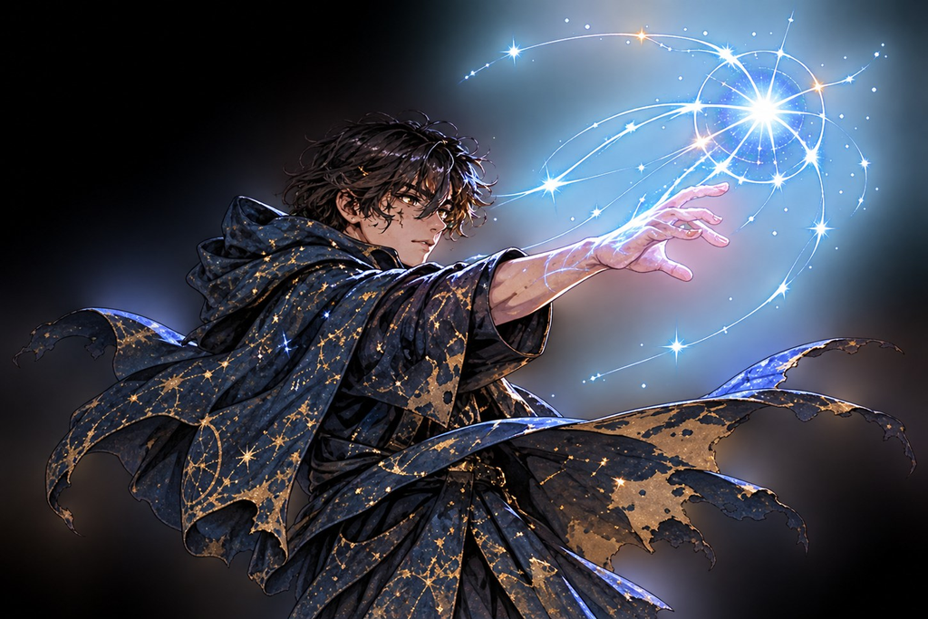

Tempo**1 A**

Gittata / area**18 m · creatura o oggetto**

Durata**Istantaneo**

Componenti**V, S**

Costo**Nessuno slot**

+6 contro CA → 1d8 radiante

Scagli una piccola luce. Se colpisci, oltre ai danni, il bersaglio emette **luce fioca entro 3 m / 10 ft** e non può beneficiare della condizione Invisible fino alla fine del tuo prossimo turno. È un effetto sul bersaglio colpito, non una lanterna costantemente portata dal gruppo. Il testo consente di bersagliare una creatura o un oggetto: non garantisce un colpo automatico contro un bersaglio invisibile.

**Progressione:** 2d8 al livello 5, 3d8 all'11, 4d8 al 17. Nessuno slot consumato.

Riferimento: Player’s Handbook 2024, edizione inglese, p. 320. Sintesi italiana per il tavolo.

CAEL VESPER / GRIMORIO / INCANTESIMOD&D 2024 · LIVELLO 3

Trucchetto di classe

# Produce Flame

Trucchetto; Evocazione — Conjuration · PHB 2024 (EN), p. 308

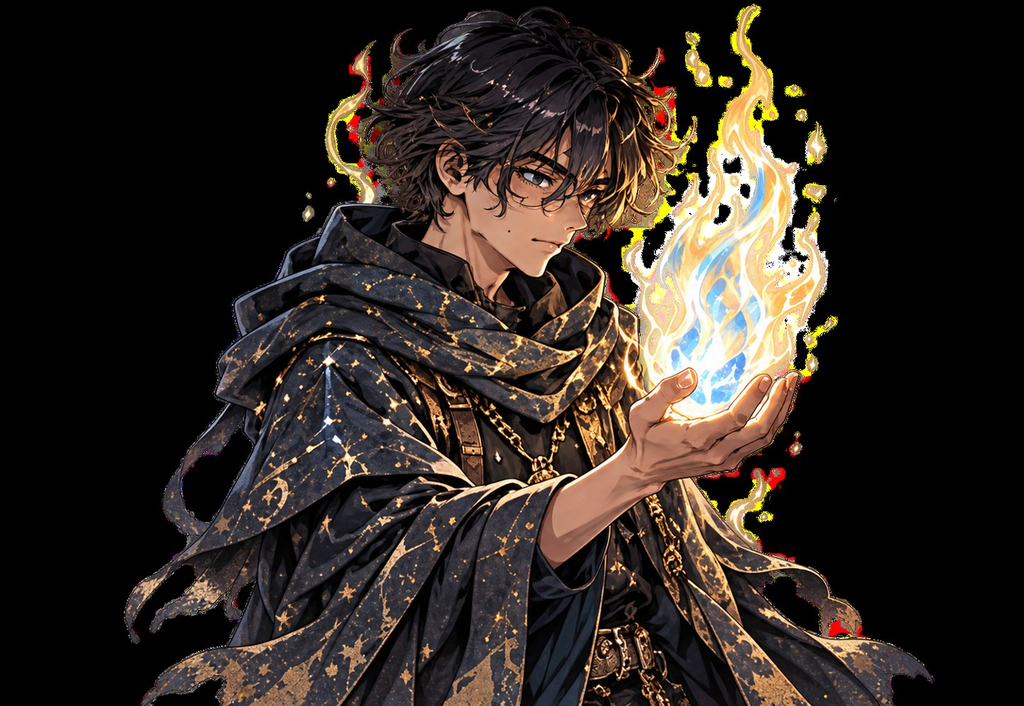

Tempo**1 AB crea · 1 A Magia attacca**

Gittata / area**Personale; attacco 18 m**

Durata**10 min · no concentrazione**

Componenti**V, S**

Costo**Nessuno slot**

+6 contro CA → 1d8 fuoco

Una fiamma appare nella tua mano. Mentre rimane nella mano, **non produce calore e non incendia nulla**. Illumina intensamente entro **6 m / 20 ft** e fiocamente per altri **6 m / 20 ft**.

Per tutta la durata puoi spendere un'azione Magia per scagliare fuoco. **Nel testo 2024 attaccare non termina l'incantesimo.** Puoi quindi creare la fiamma con l'azione bonus e attaccare con l'azione nello stesso turno; nei turni successivi basta l'azione per attaccare ancora. Rilanciare Produce Flame termina l'istanza precedente.

**Progressione:** 2d8 al livello 5, 3d8 all'11, 4d8 al 17. Non aggiungi SAG ai danni al livello attuale. Non richiede slot o concentrazione. L'idoneità come «luce viva» contro il Miasma **non è stabilita da questo incantesimo**: è una questione della campagna.

Riferimento: Player’s Handbook 2024, edizione inglese, p. 308. Sintesi italiana per il tavolo.

CAEL VESPER / GRIMORIO / INCANTESIMOD&D 2024 · LIVELLO 3

Magic Initiate · trucchetto

# Druidcraft

Trucchetto; Trasmutazione · PHB 2024 (EN), p. 266

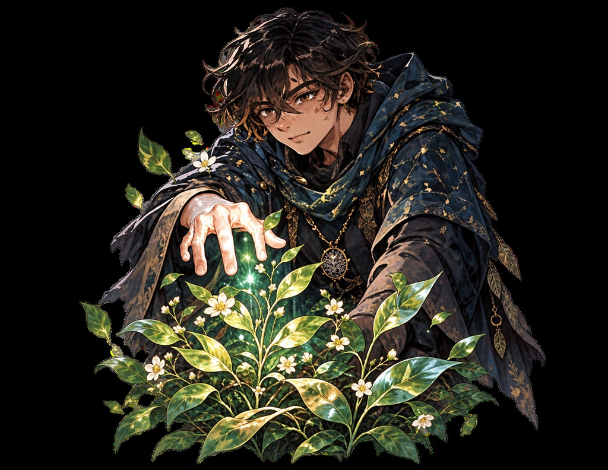

Tempo**1 A**

Gittata / area**9 m**

Durata**Istantaneo***

Componenti**V, S**

Costo**Nessuno slot**

Nessun tiro → Piccoli effetti naturali

Scegli uno degli effetti descritti: un piccolo segnale sensoriale innocuo che prevede il tempo **locale nelle prossime 24 ore**; far sbocciare un fiore, aprire un baccello o germogliare una gemma; un effetto sensoriale innocuo entro un **cubo di 1,5 m / 5 ft**; oppure **accendere o spegnere una candela, una torcia o un fuoco da campo**.

Non trasforma questi effetti in attacchi o danni. Nessun potenziamento con il livello riportato. È questo trucchetto a menzionare esplicitamente l'accensione di una torcia, a differenza della fiamma tenuta in mano di Produce Flame.

Riferimento: Player’s Handbook 2024, edizione inglese, p. 266. Sintesi italiana per il tavolo.

CAEL VESPER / GRIMORIO / INCANTESIMOD&D 2024 · LIVELLO 3

Magic Initiate · trucchetto

# Shillelagh

Trucchetto; Trasmutazione · PHB 2024 (EN), p. 316

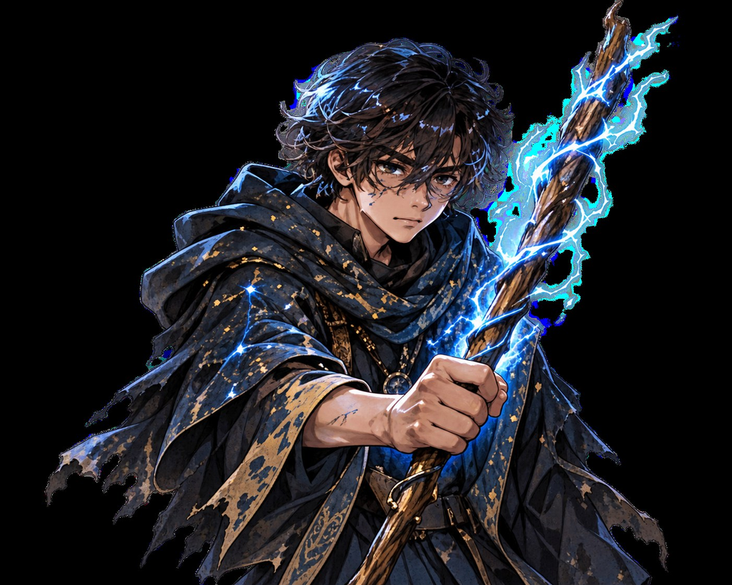

Tempo**1 AB potenzia · 1 A Attaccare**

Gittata / area**Personale · arma impugnata**

Durata**1 min · no concentrazione**

Componenti**V, S, M: vischio**

Costo**Nessuno slot**

+6 contro CA → 1d8+4 forza o contundente

Per gli attacchi in mischia con l'arma idonea puoi usare la caratteristica magica al posto di Forza sia per colpire sia per i danni. Il dado dell'arma diventa d8; quando infliggi danni scegli **forza — Force** oppure il normale tipo dell'arma, contundente per Club/Quarterstaff.

**Il lancio non comprende un attacco gratuito:** l'azione bonus potenzia l'arma, l'attacco usa la normale azione Attaccare. L'effetto termina prima della scadenza se lo rilanci o lasci andare l'arma. Non si applica al falcetto; **Club non significa Mace**.

**Progressione del dado:** d10 al livello 5, d12 all'11, 2d6 al 17. Il modificatore della caratteristica utilizzata rimane distinto dal dado.

La dotazione comprende un bastone-focus. Formalizzarne l’uso come Quarterstaff idoneo con il DM, senza aggiungere un’arma gratuita.

Riferimento: Player’s Handbook 2024, edizione inglese, p. 316. Sintesi italiana per il tavolo.

CAEL VESPER / GRIMORIO / INCANTESIMOD&D 2024 · LIVELLO 3

Preparato · 1° livello

# Healing Word

1°; Abiurazione · PHB 2024 (EN), p. 284

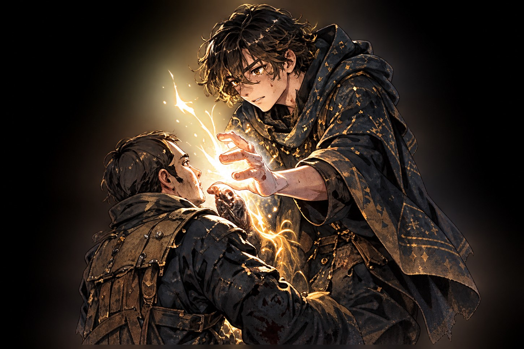

Tempo**1 AB**

Gittata / area**18 m · una creatura visibile**

Durata**Istantaneo**

Componenti**V soltanto**

Costo**1 slot di 1°**

Nessun tiro → Cura 2d4+4 PF

Non richiede tiro per colpire o TS. La differenza operativa rispetto a Cure Wounds è la cura a distanza con azione bonus, mantenendo il requisito di vedere il bersaglio.

**Con slot superiori:** +2d4 di guarigione per ogni livello dello slot oltre il primo. Al livello 2 Cael usa soltanto il profilo base.

Riferimento: Player’s Handbook 2024, edizione inglese, p. 284. Sintesi italiana per il tavolo.

CAEL VESPER / GRIMORIO / INCANTESIMOD&D 2024 · LIVELLO 3

Preparato · 1° livello

# Cure Wounds

1°; Abiurazione · PHB 2024 (EN), p. 259

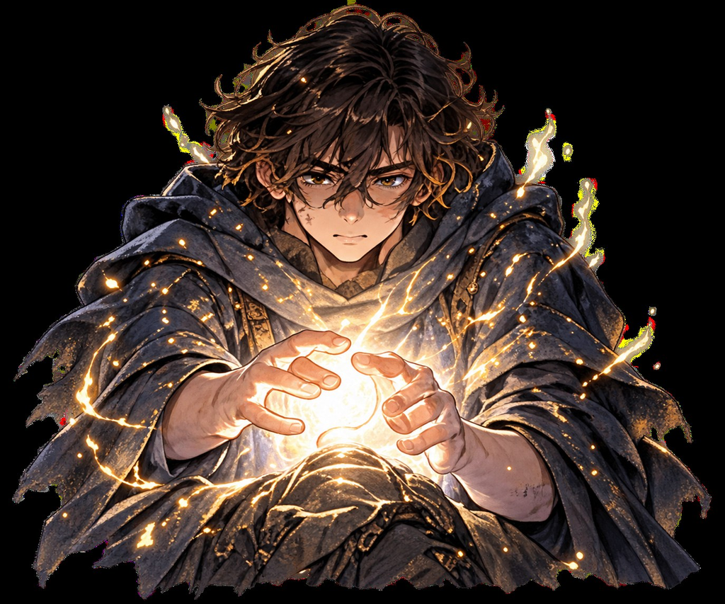

Tempo**1 A**

Gittata / area**Contatto · una creatura**

Durata**Istantaneo**

Componenti**V, S**

Costo**1 slot di 1°**

Nessun tiro → Cura 2d8+4 PF

Nessun tiro per colpire o TS. Cura più di Healing Word con il profilo base, ma richiede l'azione e il contatto. Un famiglio può consegnare il contatto alle condizioni descritte in Find Familiar.

Riferimento: Player’s Handbook 2024, edizione inglese, p. 259. Sintesi italiana per il tavolo.

CAEL VESPER / GRIMORIO / INCANTESIMOD&D 2024 · LIVELLO 3

Preparato · 1° livello

# Entangle

1°; Evocazione — Conjuration · PHB 2024 (EN), p. 268

[figure not shown]

Tempo**1 A**

Gittata / area**27 m · quadrato 6 m sul terreno**

Durata**CONC · fino a 1 min**

Componenti**V, S**

Costo**1 slot di 1°**

TS FOR CD 14 → Trattenuto + terreno difficile

Le piante rendono il terreno nell'area **difficile** per la durata; scompaiono al termine dell'incantesimo. Ogni creatura presente nell'area al momento del lancio, **eccetto Cael**, deve superare il TS oppure essere **Trattenuta — Restrained** fino al termine dell'effetto. Gli alleati non hanno un'esenzione generale.

Una creatura trattenuta può spendere **un'azione** per una prova di **Forza (Atletica) CD 14**: se riesce si libera. Questa è una prova di abilità, **non un nuovo TS**. Il testo non applica nuovamente il vincolo a chi entra nell'area dopo il lancio; resta il terreno difficile.

**Trattenuto non significa paralizzato:** velocità 0 e non aumentabile; attacchi contro la creatura con vantaggio; suoi attacchi con svantaggio; suoi TS di Destrezza con svantaggio. Può ancora attaccare rispettando tali effetti. Nessuna progressione con slot superiori riportata nella voce.

Riferimento: Player’s Handbook 2024, edizione inglese, p. 268. Sintesi italiana per il tavolo.

CAEL VESPER / GRIMORIO / INCANTESIMOD&D 2024 · LIVELLO 3

Preparato · 1° livello

# Faerie Fire

1°; Invocazione — Evocation · PHB 2024 (EN), p. 271

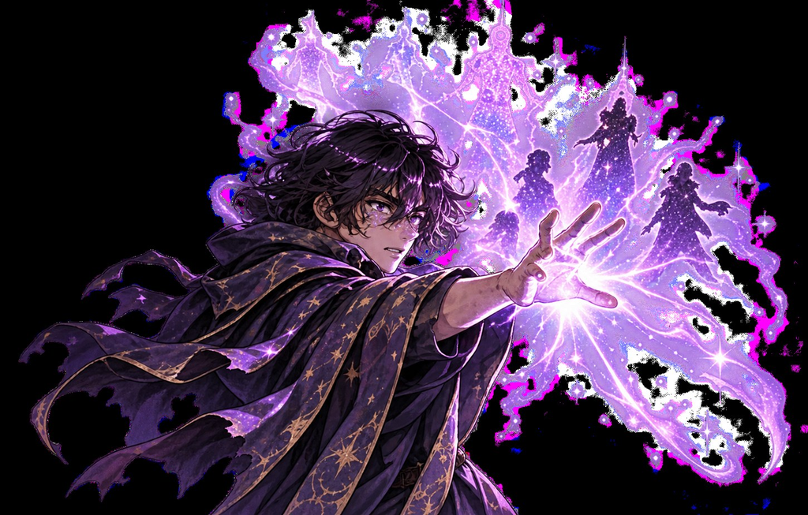

Tempo**1 A**

Gittata / area**18 m · cubo di 6 m**

Durata**CONC · fino a 1 min**

Componenti**V soltanto**

Costo**1 slot di 1°**

TS DES CD 14 → Vantaggio contro gli influenzati

Gli oggetti nel cubo vengono contornati di luce blu, verde o viola, a scelta; le creature sono contornate se falliscono il TS. Gli oggetti e le creature influenzati emettono **luce fioca entro 3 m / 10 ft** e non possono beneficiare della condizione Invisible.

Gli attacchi contro un bersaglio influenzato hanno **vantaggio se l'attaccante può vederlo**. Non infligge danni, non immobilizza e può coinvolgere anche alleati. Nessun potenziamento con slot superiori riportato nella voce.

Riferimento: Player’s Handbook 2024, edizione inglese, p. 271. Sintesi italiana per il tavolo.

CAEL VESPER / GRIMORIO / INCANTESIMOD&D 2024 · LIVELLO 3

Preparato · 1° livello

# Thunderwave

1°; Invocazione — Evocation · PHB 2024 (EN), p. 334

[figure not shown]

Tempo**1 A**

Gittata / area**Cubo di 4,5 m che origina da te**

Durata**Istantaneo**

Componenti**V, S**

Costo**1 slot di 1°**

TS COS CD 14 → 2d8 tuono + spinta 3 m

Ogni creatura nell'area effettua il TS. **Fallimento:** 2d8 danni da tuono e spinta di **3 m / 10 ft** lontano da Cael. **Successo:** metà danni, senza spinta. Gli oggetti non assicurati e interamente nel cubo vengono spinti di 3 metri. Il boato è udibile entro **90 m / 300 ft**.

Non è un'esplosione piazzabile a distanza: il cubo origina dall'incantatore. Il testo non esclude automaticamente gli alleati nell'area.

Progressione con slot superiori da verificare prima dell’uso. Il profilo attuale è 2d8 con slot di 1°.

Riferimento: Player’s Handbook 2024, edizione inglese, p. 334. Sintesi italiana per il tavolo.

CAEL VESPER / GRIMORIO / INCANTESIMOD&D 2024 · LIVELLO 3

Sempre preparato · Magic Initiate

# Goodberry

1°; Evocazione — Conjuration · PHB 2024 (EN), p. 280

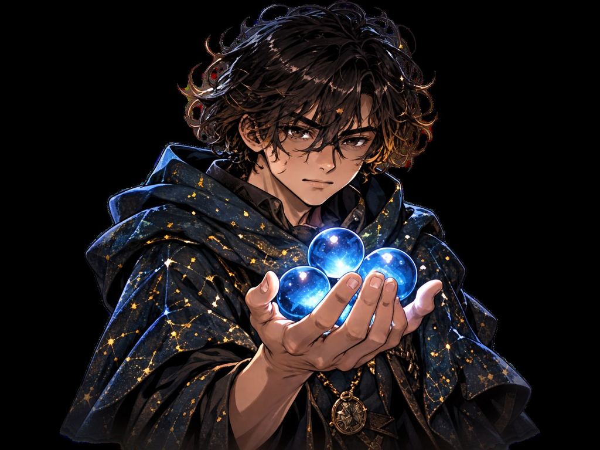

Tempo**1 A crea · 1 AB mangia**

Gittata / area**10 bacche nella tua mano***

Durata**24 h**

Componenti**V, S, M: un rametto di vischio**

Costo**1 gratis / riposo lungo o 1 slot**

Nessun tiro → 1 PF + nutrimento / bacca

La **descrizione** dice che compaiono **dieci bacche nella tua mano**. Una creatura usa **un'azione bonus** per mangiarne una: recupera **1 PF** e riceve nutrimento sufficiente per un giorno. Le bacche non consumate **scompaiono** quando termina l'incantesimo.

Il lancio non è una cura a contatto: la guarigione avviene mangiando una bacca. La voce non descrive una procedura per imboccare automaticamente una creatura incosciente; non la si aggiunge come regola certa.

La gittata resta da verificare: la descrizione fa apparire dieci bacche nella mano dell’incantatore. Non è una cura a contatto.

Riferimento: Player’s Handbook 2024, edizione inglese, p. 280. Sintesi italiana per il tavolo.

CAEL VESPER / GRIMORIO / INCANTESIMOD&D 2024 · LIVELLO 3

Sempre preparato · Druidic

# Speak with Animals

1°; Divinazione · PHB 2024 (EN), p. 318

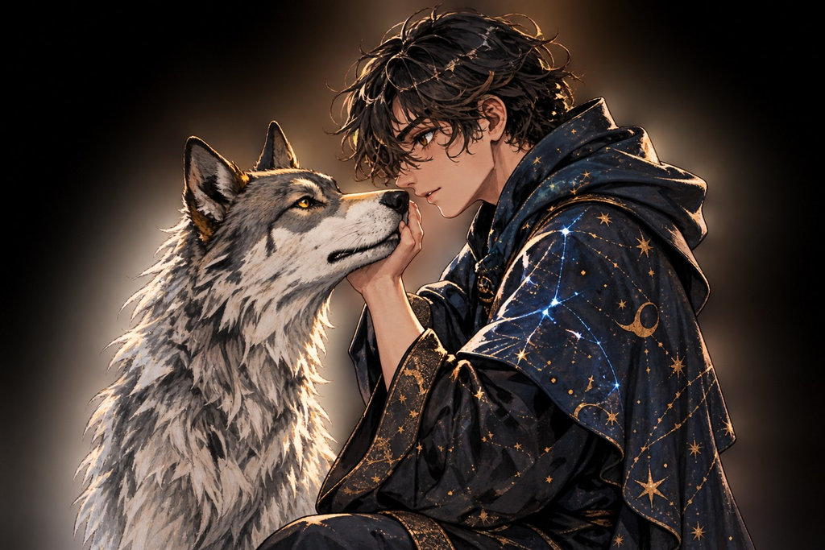

Tempo**1 A · rituale: +10 min**

Gittata / area**Personale**

Durata**10 min · no concentrazione**

Componenti**V, S**

Costo**1 slot; rituale senza slot**

Nessun tiro → Comprendi e parli con le Bestie

Comprendi e comunichi verbalmente con creature di tipo **Bestia — Beast**, potendo usare con esse le opzioni di abilità dell'azione Influence. Le informazioni dipendono da ciò che la Bestia ha percepito: il testo menziona luoghi vicini, mostri e percezioni dell'ultimo giorno, con interessi generalmente legati a sopravvivenza e compagnia.

Comunicazione non significa controllo o amicizia automatica. L'effetto riguarda le Bestie, non ogni creatura che abbia un aspetto animale. Nessun potenziamento con slot superiori riportato.

Riferimento: Player’s Handbook 2024, edizione inglese, p. 318. Sintesi italiana per il tavolo.

CAEL VESPER / GRIMORIO / PROPOSTAD&D 2024 · LIVELLO 3

PROPOSTA · Magician

# Guidance

Trucchetto; Divinazione · PHB 2024 (EN), p. 282

**Proposta, non scelta confermata.** Non aggiunta alle capacità attive.

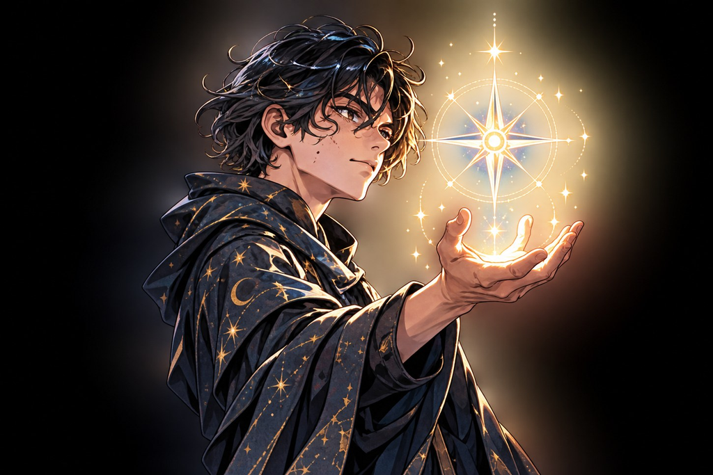

Tempo**1 A**

Gittata / area**Contatto · creatura consenziente**

Durata**CONC · fino a 1 min**

Componenti**V, S**

Costo**Nessuno slot**

Nessun tiro → +1d4 alle prove di un’abilità scelta

Tocchi la creatura e scegli un'abilità, per esempio Furtività. Finché dura l'effetto aggiunge 1d4 a **ogni** prova che utilizza quell'abilità; il testo 2024 non limita il beneficio a una sola prova. Non concede bonus ai tiri per colpire o ai tiri salvezza.

Richiedendo concentrazione, secondo la regola standard interrompe Entangle o Faerie Fire se inizi a lanciarlo mentre mantieni uno di essi. Nessuno slot consumato. La futura Star Map può fornire lo stesso trucchetto, ma non è attiva al livello 2.

Riferimento: Player’s Handbook 2024, edizione inglese, p. 282. Sintesi italiana per il tavolo.

CAEL VESPER / COMPAGNOD&D 2024 · LIVELLO 3

Grimorio illustrato

# Find Familiar

Trova Famiglio · PHB 2024 (EN), p. 272 · Wild Companion p. 81

| Campo | Incantesimo ordinario | Modalità documentata per Cael |
| --- | --- | --- |
| Livello e scuola | 1°; Evocazione — Conjuration | Invariati |
| Tempo di lancio | 1 ora; la voce ha il tag Ritual | **1 azione Magia** |
| Gittata iniziale | 3 m / 10 ft | Invariata |
| Componenti | V, S; incenso acceso da almeno 10 mo, consumato | **V, S; nessuna componente materiale** |
| Durata indicata | Istantanea; il famiglio permane secondo le regole della voce | **Scompare al termine del riposo lungo** |
| Concentrazione | No | No |
| Tipo del famiglio | Celestiale, Fatato o Immondo | **Fatato — Fey** |
| Costo | Normale accesso all'incantesimo | **Uno slot oppure un uso di Wild Shape** |

Il famiglio compare in uno spazio libero entro gittata, agisce autonomamente ma obbedisce ai tuoi comandi. Il testo nomina **Bat, Cat, Frog, Hawk, Lizard, Octopus, Owl, Rat, Raven, Spider e Weasel**. Il requisito per forme ulteriori è incompleto nella testo disponibile e non viene ricostruito a memoria. **La forma del famiglio di Cael non è ancora scelta.**

**Combattimento.** È un alleato del gruppo, tira la propria iniziativa e agisce nel proprio turno. **Non può attaccare**, ma può compiere altre azioni normalmente.

**Legame.** Entro **30 m / 100 ft** comunichi telepaticamente con lui. Con un'azione bonus puoi vedere e sentire attraverso i suoi sensi fino all'inizio del tuo prossimo turno, beneficiando dei suoi sensi speciali.

**Incantesimi a contatto.** Quando lanci un incantesimo a contatto, il famiglio può consegnare quel contatto se è entro 30 metri da te, usando **la propria reazione nel momento del lancio**. Per esempio può consegnare Cure Wounds; il tuo lancio continua a consumare la tua azione e lo slot previsto.

**Scomparsa.** A 0 PF scompare e serve un nuovo lancio per farlo ricomparire. Con un'azione Magia puoi congedarlo temporaneamente in una dimensione tascabile o definitivamente; se è temporaneamente congedato, un'azione Magia lo fa riapparire in uno spazio libero entro **9 m / 30 ft**. Quando scompare a 0 PF o nella dimensione tascabile lascia sul posto gli oggetti indossati o trasportati.

Puoi avere **un solo famiglio**. Rilanciare l'incantesimo mentre ne hai uno ne cambia la forma idonea, non crea un secondo aiutante. Nessun potenziamento con slot superiori è riportato. I metadati di classe e il testo di Wild Companion sono distinti nel registro: non si attribuisce un ulteriore lancio rituale gratuito non esplicitato dalla capacità.

**Forma non ancora scelta.** Questa capacità non seleziona automaticamente un animale. Non è disponibile un’illustrazione dedicata nel materiale esistente.

CAEL VESPER / REGOLED&D 2024 · LIVELLO 3

Grimorio illustrato

# Concentrazione e condizioni

### Concentration — regola standard

Puoi terminare la concentrazione in qualsiasi momento senza azione. La perdi **quando inizi a lanciare un altro incantesimo che la richiede** o attivi un altro effetto a concentrazione. Subendo danni, devi superare un **TS Costituzione**: la CD è **10 o metà dei danni subiti arrotondata per difetto, scegliendo il valore maggiore, fino a un massimo di 30**. Incapacitated o morte terminano la concentrazione.

Per Cael il TS ordinario è **1d20 +3**. Il **+7** e la concentrazione su più effetti sono esclusivamente la variante di campagna riportata sotto.

Fra le voci di questa scheda, **Guidance, Entangle e Faerie Fire richiedono concentrazione**. Produce Flame e Shillelagh no. Secondo il regolamento standard i tre effetti a concentrazione sono alternativi; non si può ignorare il limite perché Guidance è un trucchetto.

PHB 2024 (EN), p. 363.

### Incapacitated

Non puoi compiere **azioni, azioni bonus o reazioni**, non puoi parlare e perdi concentrazione. Se tiri l'iniziativa in questo stato hai svantaggio. Le capacità Wild Shape e, in futuro, Starry Form specificano inoltre di terminare con questa condizione; Alert non permette lo scambio di iniziativa quando uno dei due partecipanti è Incapacitated.

PHB 2024 (EN), p. 369.

### Restrained — Trattenuto

Velocità 0 e non aumentabile; attacchi contro la creatura con vantaggio; suoi attacchi e TS di Destrezza con svantaggio. Non equivale a perdere automaticamente azione e capacità di attaccare. Per liberarsi da **Entangle** si usa la procedura di quell'incantesimo, non una procedura di fuga inventata per ogni effetto che trattiene.

PHB 2024 (EN), p. 373.

### Rituali

Un incantesimo preparato con il tag Ritual può essere lanciato senza slot impiegando 10 minuti in più del tempo normale, senza aumentarne il livello. Si applica a Speak with Animals. Per Find Familiar è qui documentato l’accesso specifico di Wild Companion, non un rituale gratuito.

PHB 2024 (EN), p. 373.

CAEL VESPER / CAMPAGNAD&D 2024 · LIVELLO 3

Grimorio illustrato

# Il Dominio Oscuro

Regole di campagna, non regole del PHB. Fonti: Il Dominio Oscuro – Guida Ambientale; Prontuario Regole e Mutilazioni Dark Fantasy. Originali e pagine non verificati.

| Regola della campagna | Quanto riportato nella scheda precedente |
| --- | --- |
| Cappa d'inchiostro | Di giorno luce fioca; luna e stelle non visibili |
| Miasma notturno | Attraversare la nebbia senza «luce viva»: ogni ora **TS COS CD 13**; fallimento: **1d6 necrotici**, un livello di Esaustione e allucinazioni |
| Risveglio dei morti | Cadaveri da cremare entro **1d12 ore**, tempo determinato segretamente dal master |
| Critici brutali | Un critico naturale a segno o la riduzione a 0 PF da danni diretti attiva un tiro **d100 di mutilazione** |
| Riposi | Breve: un'ora con riparo e razioni. Lungo: otto ore in luogo realmente sicuro; otto ore nelle terre selvagge concedono soltanto un riposo breve |
| Sforzo arcano | Possibili più incantesimi con slot nello stesso turno; dal secondo, **1d6 × livello dell'incantesimo aggiuntivo**, danni non resistibili |
| Concentrazione multipla | Più effetti ammessi; con due effetti, **CD minima 20** quando subisci danni; un fallimento interrompe tutti; bonus speciale **COS + SAG = +7** con i punteggi attuali |

**Luce viva:** Produce Flame illumina ma il suo testo dice che la fiamma in mano non produce calore. L'equivalenza fra quella luce e la protezione dal Miasma **va stabilita dal DM**. Non si assegna una protezione dalla campagna soltanto perché un effetto emette luce. Lo stesso vale per le future manifestazioni stellari.

**Economia delle azioni:** la trascrizione di Sforzo arcano non concede espressamente azioni o azioni bonus aggiuntive. Non usarla per attribuirle automaticamente. Per il limite standard degli incantesimi con slot nello stesso turno non è stata recuperata una voce precisa attraverso la ricerca effettuata: non viene inventata una pagina di riferimento.

**Concentrazione multipla:** con +7 contro CD 20 serve almeno 13 sul d20 (40% di successo). I danni di Sforzo arcano e il momento in cui avvengono vanno chiariti con il DM: nessuna esenzione dai tiri di concentrazione è presunta.

CAEL VESPER / STORIAD&D 2024 · LIVELLO 3

Grimorio illustrato

# Il cielo che manca

Cael era il misuratore delle distanze tra i bracieri: contava passi, annotava sentieri che il Miasma cancellava, verificava che le carovane avessero legna sufficiente. La sua insegnante gli lasciò una carta stellare disegnata prima che il cielo diventasse nero.

Una notte guidò dodici persone attraverso un valico apparentemente sicuro; ne tornarono quattro. Non parla delle otto scomparse, ma disegna ogni notte la loro ultima posizione sulla carta. Non sa se la mappa sia una reliquia autentica, un falso o una trappola.

Per lui le stelle non sono divinità. Sono **coordinate**. Dimostrare che esistono significa dimostrare che il confine si può attraversare.

**Personalità:** curioso, metodico, ironia nera; pretende sempre un piano di fuga, diffida delle autorità ma non abbandona un compagno.

**Difetto:** a volte è disposto a rischiare troppo pur di verificare un indizio sul cielo.

**Segreto da usare col DM:** una delle otto persone scomparse aveva annotato una costellazione **impossibile** sul retro della mappa. Il suo nome è stato cancellato.

**Frase tipica:** «Non serve credere alle stelle. Serve sapere dove puntare.»

### Appunti di sessione

CAEL VESPER / AVANZAMENTOD&D 2024 · LIVELLO 3

Grimorio illustrato

# Il Circolo delle Stelle

[figure not shown]

### Star Map

Crei una carta stellare come oggetto Minuscolo, utilizzabile come focus per gli incantesimi da druido. **Mentre la impugni**, hai accesso a **Guidance e Guiding Bolt** e puoi lanciare Guiding Bolt senza slot un numero di volte pari al modificatore di Saggezza, minimo una: con i punteggi attuali **quattro volte per riposo lungo**.

Se perdi la mappa, una cerimonia di un'ora crea una sostituta e distrugge la precedente; può svolgersi durante un riposo breve o lungo. Il testo consente diverse forme dell'oggetto: non occorre assegnare subito un nuovo oggetto magico alla dotazione del livello 2.

PHB 2024 (EN), p. 88.

### Starry Form

Con **un'azione bonus** spendi un uso di Wild Shape per assumere una forma stellare invece di trasformarti in Bestia. Conservi le statistiche; emetti luce intensa entro **3 m / 10 ft**, più luce fioca per altri 3 metri. Dura **10 minuti**; termina se la congedi, senza azione, se diventi Incapacitated o se la attivi di nuovo. La voce non richiede concentrazione.

Scegli una delle tre costellazioni quando attivi la forma:

[figure not shown]

**Star Map**  
La mappa stellare come focus druidico.

[figure not shown]

**Archer · Arciere**  
Una freccia di luce stellare scagliata da Cael.

[figure not shown]

**Chalice · Calice**  
La costellazione del Calice accompagna la cura.

[figure not shown]

**Dragon · Drago**  
La costellazione del Drago sostiene la concentrazione.

[output not shown]

L'attacco dell'Arciere nei turni successivi e Healing Word richiedono entrambi l'azione bonus: non vanno sommati come se il personaggio ne avesse due. Il colpo durante l'attivazione dell'Arciere è invece esplicitamente incluso dalla capacità.

PHB 2024 (EN), p. 88.